# Reproducible Research: Assignment #1

## 1. Introduction

This report is prepared for *Assignment 1* of **Reproducible Research** course (Coursera, Data Science Specialization, Johns Hopkins Bloomberg School of Public Health).

This assignment makes use of 2-months data (October-November, 2012) from a personal activity monitoring device, which collects information about the number of steps taken by a person at 5 minute intervals throughout the day.

The dataset for analysis is stored in a comma-separated-value (CSV) file and contains 17,568 observations of 3 variables:

- **steps**: Number of steps took in a 5-minute interval (missing values are coded as NA);
- **date**: The date on which the measurement was taken (in YYYY-MM-DD format);
- **interval**: Identifier for the 5-minute interval in which measurement was taken.

## 2. Loading and preprocessing the data

```r
# Unzip the archive
# Load the data into R
# Converting date variable from factor to date format

unzip("activity.zip")
activity<-read.csv("activity.csv")
activity$date<-as.Date(activity$date)
```

## 3. What is mean total number of steps taken per day?

```r
# Lets aggregate total number of steps taken by date
# aggregate() by default ignores NAs in the data

activityDay<-aggregate(steps ~ date, data=activity, sum)
head(activityDay)
```

```
##         date steps
## 1 2012-10-02   126
## 2 2012-10-03 11352
## 3 2012-10-04 12116
## 4 2012-10-05 13294
## 5 2012-10-06 15420
## 6 2012-10-07 11015
```

```r
# Calculating mean and median of the total number of steps taken per day

meanDay <- mean(activityDay$steps)
medianDay <- median(activityDay$steps)
meanDay
```

```
## [1] 10766.19
```

```r
medianDay
```

```
## [1] 10765
```

So, the mean and median number of steps taken per day are very close. It means that our dataset is not much skewed and does not contains large outliers.

```r
# For this code to work 'ggplot2' package for making graphs and diagrams
# must be preinstalled
library(ggplot2)
```

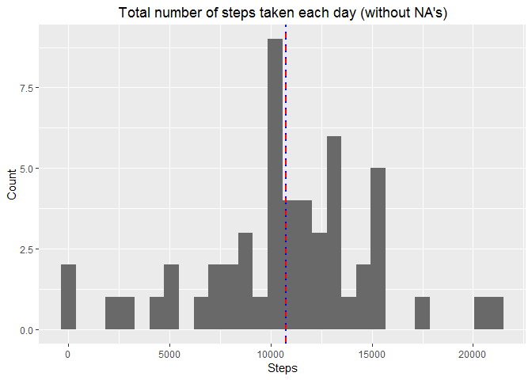

```r
# Because the mean (red dashed line) and the median (blue dotted line)
# of total number of steps taken per day are so close
# you can't see them clearly as separate lines on the graph

ggplot(data=activityDay, aes(activityDay$steps))+ geom_histogram(fill = "dimgray") + ggtitle("Total number of steps taken each day (without NA's)") + xlab("Steps") + ylab("Count")+ geom_vline(aes(xintercept=meanDay), color="red", linetype="dashed", size=1) + geom_vline(aes(xintercept=medianDay), color="blue", linetype="dotted", size=1) + theme(plot.title = element_text(hjust = 0.5))
```

## 4. What is the average daily activity pattern?

```r
# Lets aggregate total number of steps taken by interval (averaged across all days)
# And determine interval which on average contains the maximum number of steps taken

activityInt<-aggregate(steps ~ interval, data=activity, mean)
head(activityInt)
```

```
##   interval     steps
## 1        0 1.7169811
## 2        5 0.3396226
## 3       10 0.1320755
## 4       15 0.1509434
## 5       20 0.0754717
## 6       25 2.0943396
```

```r
maxSteps <- max(activityInt$steps)
maxSteps
```

```
## [1] 206.1698
```

```r
maxStepsInt <- activityInt[which(activityInt$steps==max(activityInt$steps)), 1]
maxStepsInt
```

```
## [1] 835
```

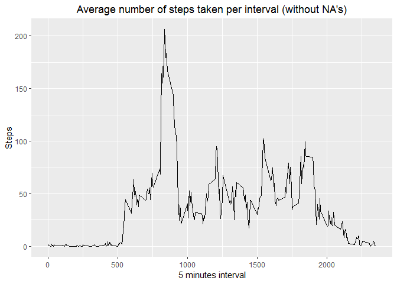

```r
# Time series plot
ggplot(activityInt, aes(interval, steps)) + geom_line() + ggtitle("Average number of steps taken per interval (without NA's)") + xlab("5 minutes interval") + ylab("Steps") + theme(plot.title = element_text(hjust = 0.5))
```

## 5. Imputing missing values

`activity` dataset contains 2304 NA values - intervals with undefined number of steps taken. Its presence may introduce bias into some calculations or summaries of the data. Lets adopt some strategy to fill the gaps in data.

```r
# Total number of missing values
sum(is.na(activity$steps))
```

```
## [1] 2304
```

```r
# Lets do some data mining

# How much days do we have in our dataset?
length(unique(activity$date))
```

```
## [1] 61
```

```r
# How much days with NA values do we have in our dataset?
not<-is.na(activity$steps)
activityNA<-activity[not,]
length(unique(activityNA$date))
```

```
## [1] 8
```

```r
# So, among 61 days only 8 contain NAs
```

```r
# The next step is to determine whether there are any "empty" days in the dataset
# (where each value is NA)
# Each day has 288 observations (24 hours * 12 five minutes intervals)
# Lets see how many NAs we have for each day containing NAs

aggregate(interval ~ date, data=activityNA, length)
```

```
##         date interval
## 1 2012-10-01      288
## 2 2012-10-08      288
## 3 2012-11-01      288
## 4 2012-11-04      288
## 5 2012-11-09      288
## 6 2012-11-10      288
## 7 2012-11-14      288
## 8 2012-11-30      288
```

```r
# So, we have no partially filled data - its either we have full day observations or no observations at all
# Therefore, we cannot use strategy "mean/median for that day" for imputting missing values
# The only option left is "mean for 5-minutes interval"
```

```r
# Lets first create dataset that doesn't contain NAs

activityFull <- activity[!not, ]

# Now we have 3 datasets to work with:
# 1 - activityFull - contains only "good" observations
# 2 - activityNA - contains only "bad" observations
# 3 - activityInt - contains means for 5-minutes intervals averaged across all days

# Lets load plyr package we will need later on
library(plyr)

# Our transformation will consist of several steps

# 1. Remove `steps` column from `activityNA` (all values are NAs)
activityNA<-activityNA[, 2:3]

# 2. Join second and third datasets by `interval` column
activityNAfilled<-join(activityNA, activityInt, by = "interval")
activityNAfilled<-activityNAfilled[, c(3,1,2)] # rearranging the columns' order

# 3. Join 'activityFull' and 'activityNAfilled'
activityNew<-rbind(activityFull, activityNAfilled)
activityNew<-activityNew[order(activityNew$date),] # sort according to date
rownames(activityNew)<-NULL # reset indexes in data frame
```

```r
# Histogram of the total number of steps taken each day
# with mean and median reported
activityDayNew <- aggregate(steps ~ date, data=activityNew, sum)

meanDayNew <- mean(activityDayNew$steps)
medianDayNew <- median(activityDayNew$steps)
meanDayNew
```

```
## [1] 10766.19
```

```r
medianDayNew
```

```
## [1] 10766.19
```

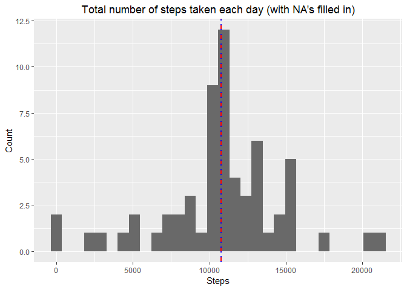

```r
ggplot(data=activityDayNew, aes(activityDayNew$steps))+ geom_histogram(fill = "dimgray") + ggtitle("Total number of steps taken each day (with NA's filled in)") + xlab("Steps") + ylab("Count") + geom_vline(aes(xintercept=meanDayNew), color="red", linetype="dashed", size=1)+ geom_vline(aes(xintercept=medianDayNew), color="blue", linetype="dotted", size=1) + theme(plot.title = element_text(hjust = 0.5))
```

As we see, after inputting missing values we get slightly different estimate of the total number of steps taken per day median (it approached mean), but the mean remained the same.

## 6. Are there differences in activity patterns between weekdays and weekends?

```r
# Lets create a new columon in our dataset indicating whether
# it's weekday or weekend
activityNew$weekdays<-as.factor(weekdays(activityNew$date))
levels(activityNew$weekdays)
```

```
## [1] "воскресенье" "вторник"     "понедельник" "пятница"     "среда"
## [6] "суббота"     "четверг"
```

```r
recode<-list("weekday"=levels(activityNew$weekdays)[c(2,3,4,5,7)], "weekend"= levels(activityNew$weekdays)[c(1,6)])
levels(activityNew$weekdays)<-recode # replacing days of the week  by 'weekday'-'weekend'

# Lets separate the dataset into 2 - for weekdays and weekends
activityWD<-activityNew[which(activityNew$weekdays=="weekday"),]
activityWE<-activityNew[which(activityNew$weekdays=="weekend"),]

# Lets aggregate it now by intervals
activityWDint<-aggregate(steps ~ interval, data=activityWD, mean)
activityWEint<-aggregate(steps ~ interval, data=activityWE, mean)

# Lets compare the average number of steps taken on weekdays and weekends
sum(activityWDint$steps)
```

```
## [1] 10255.85
```

```r
sum(activityWEint$steps)
```

```
## [1] 12201.52
```

So, as we could have expected average number of steps taken on weekends is greater than that on weekdays.

```r
# For this code to work `grid` and `greeextract` packages must be preinstalled
library(grid)
library(gridExtra)
```

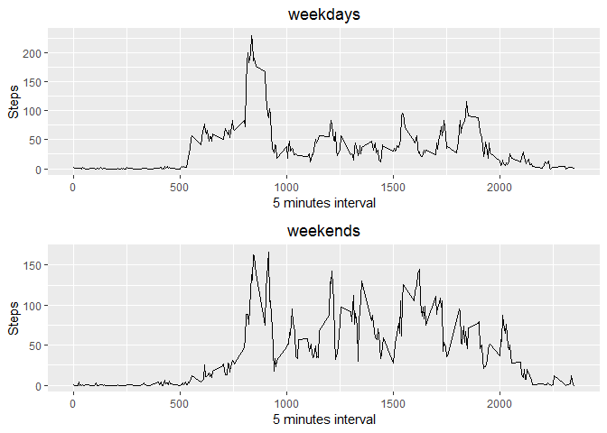

```r
# Drawing separate graphs to compare daily activity patterns for weekdays and weekends
WD<-ggplot(activityWDint, aes(interval, steps)) + geom_line() + ggtitle("weekdays") + xlab("5 minutes interval") + ylab("Steps") + theme(plot.title = element_text(hjust = 0.5))
WE<-ggplot(activityWEint, aes(interval, steps)) + geom_line() + ggtitle("weekends") + xlab("5 minutes interval") + ylab("Steps") + theme(plot.title = element_text(hjust = 0.5))
grid.arrange(WD, WE, nrow=2)
```